# Machine learning prediction of cattle supply sheds

Erasmus

2024-03-23

Machine learning prediction of cattle supply sheds - i.e. the proportion of cattle sourced per municipality.

### Load data

```r
# Logistic hub data
lh <-
  s3read_using(
    object = "brazil/logistics/slaughterhouses/slaughterhouse_map_v3/2022-06-09-br_beef_logistics_map_v3.csv",
    delim = ";",
    FUN = read_delim,
    col_types = cols(CNPJ = col_character(),
                     GEOCODE = col_character(),
                     INSPECTION_NUM = col_character()),
    opts = c("check_region" = T),
    bucket = ts
  )


# Clean columns
lh <- lh %>%
  mutate(CNPJ8 = str_sub(CNPJ, start = 1, end = 8)) %>%
  mutate(REGION = case_when(
      STATE %in% c("DF", "GO", "MT", "MS") ~ "Centro-Oeste",
      STATE %in% c("AL", "BA" , "CE", "MA", "PB", "PE", "PI", "RN", "SE") ~ "Nordeste",
      STATE %in% c("AC", "AP", "AM", "PA", "RO", "RR", "TO") ~ "Norte",
      STATE %in% c("ES", "MG", "RJ", "SP") ~ "Sudeste",
      STATE %in% c("PR", "SC", "RS") ~ "Sul",
      TRUE ~ NA_character_
      ),
      REGION = str_to_upper(REGION)) %>%
  rename(LH_GEOCODE = GEOCODE)


# Supply sheds
ss <- s3read_using(
  object = "brazil/logistics/gta/network/BOV/SUPPLY_SHED/2024_MUNICIPAL_PER_CNPJ8/JSON/CNPJ8_SUPPLY_SHEDS.json",
  FUN = fromJSON,
  bucket = ts
)


# Drop supply sheds, that on second thoughts I think look unreliable
# ... i.e. probably based on a biased subset of GTAs
ss <- ss %>%
  filter(!CNPJ8 %in% c("02307127",
                       "03143650",
                       "04304360", #SP
                       "05529476", #GO, with sourcing in PA
                       "05633835", #PI
                       "05802673", #PI
                       "05796832", #PA
                       "02307127", #CE
                       "03143650" #RS
                       ),
         !(CNPJ8 == "02591772" & LH_GEOCODE == "3502606"),
         !(CNPJ8 == "02916265" & LH_GEOCODE == "3502101"))


# Cattle herd data
ppm <- s3read_using(
  object = "brazil/production/statistics/ibge/cattle/ppm/out/PPM_BOV_HERD_1974_2022.csv",
  FUN = read_delim,
  delim = ";",
  bucket = ts,
  col_types = cols(GEOCODE = col_character())
)
ppm_2022 <- ppm %>% filter(YEAR == 2022) %>% select(-YEAR)


# Load SIGSIF data on the origin of cattle slaughtered in each state
# ... keep only relevant columns, drop unknown GEOCODEs
# ... ensure that the sum of the proportions (PROP_FLOWS) per state sums to 1.
sigsif_summary <-
  s3read_using(
    object = "brazil/production/statistics/sigsif/out/old/br_bovine_slaughter_2015_2020.csv",
    FUN = read_delim,
    col_types = cols(GEOCODE = col_character()),
    delim = ";",
    bucket = ts,
    opts = c("check_region" = T)
  )
sigsif_summary <- sigsif_summary %>%
  filter(GEOCODE != "XXXXXXX") %>%
  group_by(STATE_SLAUGHTER) %>%
  mutate(TOTAL_PROP_FLOWS = sum(PROP_FLOWS)) %>%
  ungroup() %>%
  mutate(SIGSIF_PROP_FLOWS = PROP_FLOWS / TOTAL_PROP_FLOWS) %>%
  select(STATE_SLAUGHTER,
         GEOCODE,
         SIGSIF_PROP_FLOWS)


# Inter-municipal travel distances
# Load distance matrix
if(fs::file_exists(here::here("tmp/DISTANCE_MATRIX_2016.csv"))){
  dist_matrix <-
    read_delim(
      here::here("tmp/DISTANCE_MATRIX_2016.csv"),
      delim = ";",
      col_types = cols(
        Origin = col_character(),
        Destination = col_character(),
        Total_Length = col_double()
      )
    )
} else {
  dist_matrix <- read_delim(
    get_object("brazil/logistics/cost_distance_matrices/DISTANCE_MATRIX_2016.csv",
               "trase-storage"),
    delim = ";",
    col_types = cols(Origin = col_character(),
                     Destination = col_character(),
                     Total_Length = col_double())
  )
}
names(dist_matrix) <- str_to_upper(names(dist_matrix))
dist_matrix <- dist_matrix %>%
  mutate(DISTANCE_KM = TOTAL_LENGTH / 1000) %>%
  select(-TOTAL_LENGTH)


# Load the urban/rural classification of each municipality
path <- "brazil/auxiliary/urbanisation/RurUrb"
keys <- map_chr(get_bucket(ts, prefix = path), "Key")
walk(keys, ~ save_object(., ts, file = str_c(tempdir(),"/", basename(.))))
objects <- list.files(tempdir(), pattern = "RurUrb", full.names = TRUE)
objects_main <- objects[grepl("\\.shp$", objects)]
urban <- read_sf(objects_main)
urban <- urban %>%
  st_drop_geometry() %>%
  distinct(BaseRurU_1, Tipologia_) %>%
  rename(GEOCODE = BaseRurU_1,
         MUNI_CLASSIFICATION = Tipologia_) %>%
  mutate(GEOCODE = as.character(GEOCODE),
         MUNI_CLASSIFICATION = str_to_upper(MUNI_CLASSIFICATION))
rm(path, keys, objects, objects_main)
```

Load municipal borders, and make a data.frame which identifies neighbouring municipalities

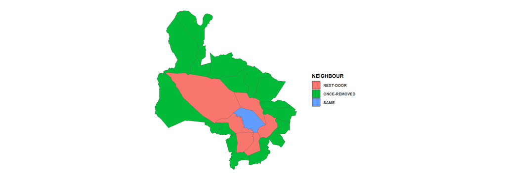

```r
# Load municipal borders
munis <-
  s3read_using(
    object = "brazil/spatial/BOUNDARIES/ibge/old/boundaries municipalities/MUNICIPALITIES_BRA.geojson",
    FUN = read_sf,
    bucket = "trase-storage",
    opts = c("check_region" = T)
  )
muni_centroids <- st_centroid(munis)


# Load state borders shp
path <- "brazil/spatial/BOUNDARIES/ibge/old/boundaries states/"
keys <- map_chr(get_bucket(ts, prefix = path), "Key")
walk(keys, ~ save_object(., ts, file = str_c(tempdir(),"/", basename(.))))
objects <- list.files(tempdir(), pattern = "BRUFE250GC_SIR", full.names = TRUE)
objects_main <- objects[grepl("\\.shp", objects)]
states <- read_sf(objects_main)
rm(path, keys, objects, objects_main)
states <- states %>%
  mutate(NM_ESTADO = str_trans(NM_ESTADO))


# Identify directly neighbouring municipalities
# ... Inspired by https://github.com/r-spatial/sf/issues/234
neighbour_mtx <- st_intersects(munis, munis)
neighbour_df <- as.data.frame(neighbour_mtx) %>%
  janitor::clean_names("screaming_snake")
munis_df <- munis %>%
  st_drop_geometry() %>%
  mutate(ROW_ID = row_number()) %>%
  select(ROW_ID, GEOCODE)
neighbour_df <-
  neighbour_df %>%
  left_join(munis_df, by = "ROW_ID") %>%
  rename(FOCAL_GEOCODE = GEOCODE) %>%
  left_join(munis_df, by = c("COL_ID" = "ROW_ID")) %>%
  rename(NEIGHBOUR_GEOCODE = GEOCODE) %>%
  mutate(NEIGHBOUR = ifelse(FOCAL_GEOCODE == NEIGHBOUR_GEOCODE, "SAME", "NEXT-DOOR")) %>%
  select(FOCAL_GEOCODE, NEIGHBOUR_GEOCODE, NEIGHBOUR) %>%
  as_tibble()
stopifnot(any(is.na(neighbour_df$NEIGHBOUR_GEOCODE)) == FALSE)
stopifnot(any(is.na(neighbour_df$FOCAL_GEOCODE)) == FALSE)


# Identify neighbouring municipalities, one step removed
# ... i.e. Neighbours of neighbours
next_neighbours_df <- left_join(neighbour_df, neighbour_df, by = c("NEIGHBOUR_GEOCODE" = "FOCAL_GEOCODE"), suffix = c("_ORIGINAL", "_NEXTDOOR"), relationship = "many-to-many") %>%
  filter(FOCAL_GEOCODE != NEIGHBOUR_GEOCODE,
         NEIGHBOUR_GEOCODE != NEIGHBOUR_GEOCODE_NEXTDOOR,
         FOCAL_GEOCODE != NEIGHBOUR_GEOCODE_NEXTDOOR) %>%
  distinct(FOCAL_GEOCODE, NEIGHBOUR_GEOCODE_NEXTDOOR) %>%
  as_tibble() %>%
  mutate(NEIGHBOUR = "ONCE-REMOVED") %>%
  rename(NEIGHBOUR_GEOCODE = NEIGHBOUR_GEOCODE_NEXTDOOR)


# Remove duplicates (municipalities which are both direct neighbours and also once-removed neighbours
next_neighbours_df <- left_join(next_neighbours_df, neighbour_df, by = c("FOCAL_GEOCODE", "NEIGHBOUR_GEOCODE")) %>%
  mutate(NEIGHBOUR = coalesce(NEIGHBOUR.y, NEIGHBOUR.x)) %>%
  select(FOCAL_GEOCODE, NEIGHBOUR_GEOCODE, NEIGHBOUR)


# Join the immediate and next-door neighbours df
neighbour_all_df <- bind_rows(neighbour_df, next_neighbours_df) %>%
  distinct()


# Check no GEOCODE pairs with multiple classifications (same, neighbour, neighbour-one-removed)
stopifnot(
  neighbour_all_df %>% group_by(FOCAL_GEOCODE, NEIGHBOUR_GEOCODE) %>% count() %>% filter(n > 1) %>% nrow() == 0
  )


# Visualise an example to check it looks OK
focal_muni <- neighbour_all_df %>% sample_n(size = 1) %>% pull(FOCAL_GEOCODE)
munis_to_plot <- inner_join(munis, neighbour_all_df %>% filter(FOCAL_GEOCODE == focal_muni), by = c("GEOCODE" = "NEIGHBOUR_GEOCODE"))
ggplot() +
  geom_sf(data = munis_to_plot, aes(fill = NEIGHBOUR) ) +
  theme_trase() +
  coord_sf(datum = NA) +
  theme(axis.text =  element_blank())
```

```r
# Load the municipal sizes
# muni_size <- read_excel("C:/Users/erasm/Dropbox/post_doc/Louvain/TRASE_relevant/useful_titbits/MUNICIPALITY_SIZES_2016.xls")
# mean_muni_size <- muni_size %>%
#   rename(TWO_DIGIT_CODE = CD_GCUF) %>%
#   group_by(TWO_DIGIT_CODE) %>%
#   summarise(MEAN_AREA_KM2 = mean(AR_MUN_2016)) %>%
#   ungroup() %>%
#   arrange(desc(MEAN_AREA_KM2)) %>%
#   as.data.frame()


# Identify the distance to the nearest SIF and SIE slaughterhouse per municipality
# ... Note I keep just the two closest distances in each case
# ... when joining these data to the data-frame, this allows us to find the nearest slaughterhouse
# ... which is NOT the slaughtehrouse-of-interest (hence the need for two results here)
sifs <- lh %>%
  filter(INSPECTION_LEVEL == "SIF") %>%
  distinct(CNPJ8, LH_GEOCODE)
sif_distances <- inner_join(dist_matrix, sifs, by = c("DESTINATION" = "LH_GEOCODE"), relationship = "many-to-many") %>%
  group_by(ORIGIN) %>%
  arrange(DISTANCE_KM) %>%
  slice(1:2) %>%
  ungroup() %>%
  select(ORIGIN,
         DISTANCE_KM_TO_NEXT_NEAREST_SIF = DISTANCE_KM,
         CNPJ8_SIF = CNPJ8)
sies <- lh %>%
  filter(INSPECTION_LEVEL == "SIE") %>%
  distinct(CNPJ8, LH_GEOCODE)
sie_distances <- inner_join(dist_matrix, sies, by = c("DESTINATION" = "LH_GEOCODE"), relationship = "many-to-many") %>%
  group_by(ORIGIN) %>%
  arrange(DISTANCE_KM) %>%
  slice(1:2) %>%
  ungroup() %>%
  select(ORIGIN,
         DISTANCE_KM_TO_NEXT_NEAREST_SIE = DISTANCE_KM,
         CNPJ8_SIE = CNPJ8)
rm(sifs, sies)
```

This is what we want to predict:

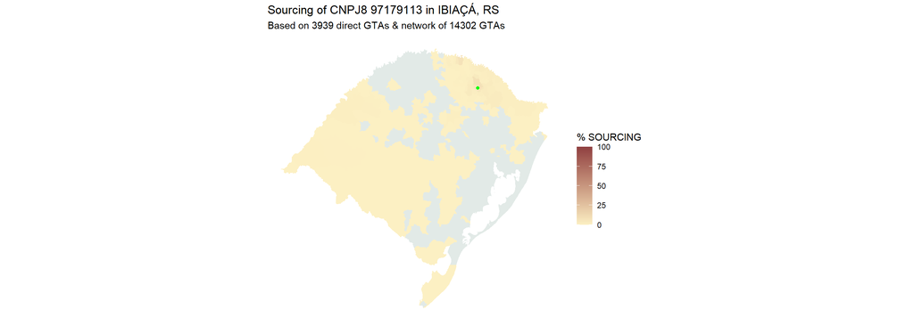

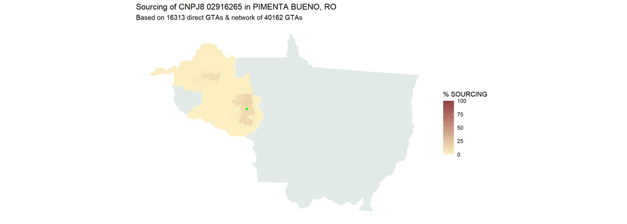

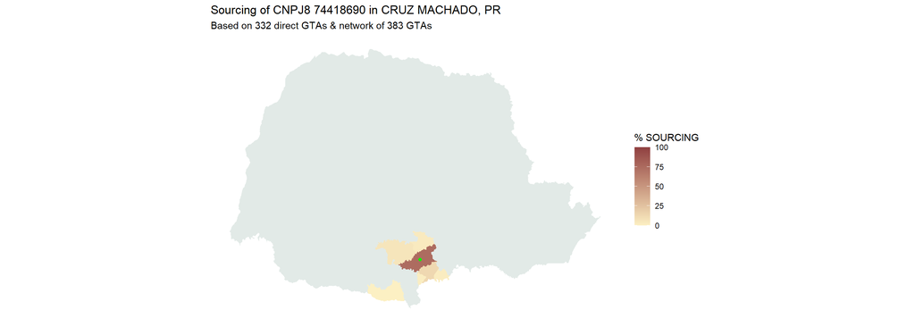

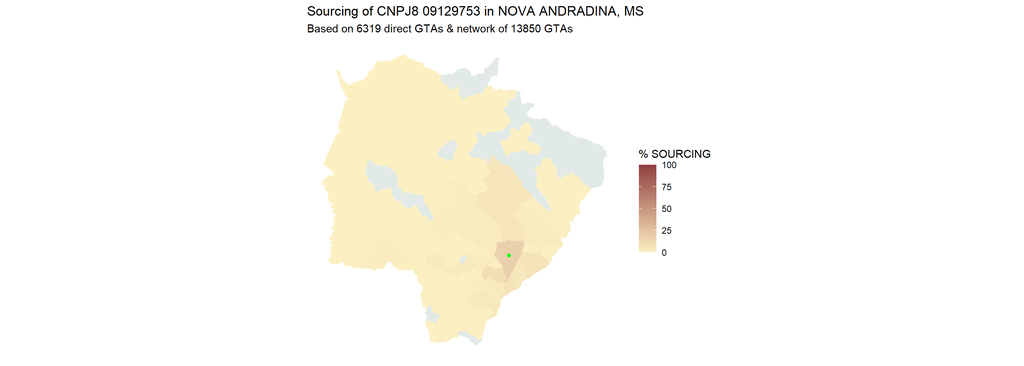

```r
fn_plot_cnpj8_supply_sheds <- function(CNPJ8, LH_GEOCODE, SUPPLY_SHED, TOTAL_NUM_DIRECT_GTAS, TOTAL_NUM_GTAS, muni_centroids, states, scale_max) {
  munis_to_plot <-
    inner_join(munis, SUPPLY_SHED, by = c("GEOCODE" = "GEOCODE")) %>%
    mutate(TWO_DIGIT_CODE = str_sub(GEOCODE, start = 1, end = 2)) %>%
    left_join(state_dic, by = "TWO_DIGIT_CODE")
  location <-
    muni_centroids %>%
    filter(GEOCODE == LH_GEOCODE) %>%
    mutate(
      x = map_dbl(geometry, 1),
      y = map_dbl(geometry, 2),
      TWO_DIGIT_CODE = str_sub(GEOCODE, start = 1, end = 2)
    ) %>%
    left_join(state_dic, by = "TWO_DIGIT_CODE")
  p <- ggplot() +
    geom_sf(data = states %>% filter(NM_ESTADO %in% unique(munis_to_plot$STATE_NAME)), fill = trase_country_background, col = trase_map_border) +
    geom_sf(data = munis_to_plot, aes(fill = PROP_FLOWS * 100), col = NA) +
    geom_point(data = location, aes(x = x, y = y), col = "green") +
    scale_fill_gradient(
    name = bquote('% SOURCING'),
    low = trase_palettes$MapsNegative[[1]],
    high = trase_palettes$MapsNegative[[9]],
    limits = c(0, 100)
  ) +
    theme_minimal() +
    coord_sf(datum = NA) +
    labs(
      title = paste0("Sourcing of CNPJ8 ", CNPJ8, " in ", location$NAME, ", ", location$STATE_ABBR),
      subtitle = paste0("Based on ", TOTAL_NUM_DIRECT_GTAS, " direct GTAs & network of ", TOTAL_NUM_GTAS, " GTAs")
    ) +
    theme(axis.title = element_blank())
  return(p)
}
pmap(
  .l = ss %>% sample_n(size = 4),
  .f = fn_plot_cnpj8_supply_sheds,
  muni_centroids = muni_centroids,
  states = states,
  scale_max = max(supply_sheds_cnpj8$PROP_FLOWS) + 2
)
```

### Prepare data

776 slaughterhouse supply sheds are available from the following states:

```r
ss %>%
  mutate(TWO_DIGIT_CODE = str_sub(LH_GEOCODE, start = 1, end = 2)) %>%
  left_join(state_dic, by = "TWO_DIGIT_CODE") %>%
  group_by(STATE_ABBR) %>%
  count() %>%
  arrange(desc(n)) %>%
  as.data.frame()
```

```
##    STATE_ABBR   n
## 1          RS 146
## 2          PR 111
## 3          MG  79
## 4          GO  64
## 5          MT  53
## 6          MS  48
## 7          PA  47
## 8          SC  43
## 9          SP  39
## 10         BA  28
## 11         AL  25
## 12         RO  23
## 13         TO  16
## 14         RJ  14
## 15         MA  12
## 16         ES  11
## 17         CE   5
## 18         PE   3
## 19         PI   3
## 20         SE   2
## 21         AM   1
## 22         DF   1
## 23         PB   1
## 24         RN   1
```

```r
# Note, this doesn't include the municipalities where zero flows were found
# ... to correctly train the model on all municipalities, I therefore expand `ss`
# ... to add in the missing zero values
ss_all <- ss %>%
  unnest(cols = c(SUPPLY_SHED)) %>%
  filter(!grepl("AGGREGATED", GEOCODE)) %>%
  select(-BIOME) %>%
  complete(
    GEOCODE,
    nesting(CNPJ8, LH_GEOCODE, TOTAL_NUM_DIRECT_GTAS, TOTAL_NUM_GTAS),
    fill = list(PROP_FLOWS = 0)
    )


# Check the complete() worked, and all municipalities are included in the supply shed of each slaughterhouse
# ... i.e. the number of times each municipality appears is the same (once per slaughterhouse)
stopifnot(
  ss_all %>%
    group_by(GEOCODE) %>%
    count() %>%
    ungroup() %>%
    distinct(n) %>%
    nrow() == 1
)
```

The data.frame used to construct the model is:

```r
# Make a single dataframe with all the relevant data
df <- lh %>%
  select(CNPJ8, LH_GEOCODE, REGION, STATE, TYPE, INSPECTION_LEVEL) %>%
  left_join(ss_all, by = c("CNPJ8", "LH_GEOCODE"), relationship = "many-to-many") %>%
  select(-TOTAL_NUM_DIRECT_GTAS, -TOTAL_NUM_GTAS) %>%
  left_join(ppm_2022, by = "GEOCODE", relationship = "many-to-one") %>%
  left_join(urban, by = c("LH_GEOCODE" = "GEOCODE"), relationship = "many-to-one") %>%
  rename(LH_CLASSIFICATION = MUNI_CLASSIFICATION) %>%
  left_join(urban, by = c("GEOCODE" = "GEOCODE"), relationship = "many-to-one") %>%
  rename(GEOCODE_CLASSIFICATION = MUNI_CLASSIFICATION) %>%
  left_join(sigsif_summary, by = c("STATE" = "STATE_SLAUGHTER", "GEOCODE")) %>%
  mutate(PROP_FLOWS = replace_na(PROP_FLOWS, 0),
         NUM_HEAD = replace_na(NUM_HEAD, 0),
         SIGSIF_PROP_FLOWS = replace_na(SIGSIF_PROP_FLOWS, 0)) %>%
  left_join(dist_matrix, by = c("LH_GEOCODE" = "DESTINATION", "GEOCODE" = "ORIGIN")) %>%
  left_join(neighbour_all_df, by = c("LH_GEOCODE" = "FOCAL_GEOCODE", "GEOCODE" = "NEIGHBOUR_GEOCODE")) %>%
  mutate(NEIGHBOUR = ifelse(is.na(NEIGHBOUR), "NOT NEIGHBOUR", NEIGHBOUR)) %>%
  mutate(SAME_STATE = ifelse(str_sub(LH_GEOCODE, start = 1, end = 2) == str_sub(GEOCODE, start = 1, end = 2), TRUE, FALSE)) %>%
  distinct()


# Add in missing data - these are cases where our transport matrix is missing municipality-pairs.
# ... I took the numbers from: https://www.freemaptools.com/how-far-is-it-between.htm
df <- df %>%
  mutate(
    DISTANCE_KM = case_when(
      LH_GEOCODE == "1502400" & GEOCODE == "1504901" ~ 146.923,
      LH_GEOCODE == "1502301" & GEOCODE == "1504901" ~ 241.071,
      LH_GEOCODE == "1501709" & GEOCODE == "1504901" ~ 278.366,
      LH_GEOCODE == "1501303" & GEOCODE == "1504901" ~ 67.096,
      LH_GEOCODE == "4307906" & GEOCODE == "4314548" ~ 25.709,
      LH_GEOCODE == "2610707" & GEOCODE == "2616183" ~ 136.084,
      LH_GEOCODE == "2616407" & GEOCODE == "2616183" ~ 97.839,
      LH_GEOCODE == "4316758" & GEOCODE == "4314548" ~ 105.442,
      TRUE ~ DISTANCE_KM
    )
  )


# Drop rows with NAs, these are because of gaps in the various datasets
df <- df %>%
  drop_na(GEOCODE) %>%
  drop_na(DISTANCE_KM) %>%
  drop_na(LH_CLASSIFICATION) %>%
  drop_na(GEOCODE_CLASSIFICATION)


# Add in the distance to the nearest SIF/SIE slaughterhouse (which is no the slaughterhouse-of-interest)
# NB a small number of duplicate rows are introduced, but this won't affect the modelling much
chk <- nrow(df)
df <- inner_join(df,
                 sif_distances,
                 by = c("GEOCODE" = "ORIGIN"),
                 relationship = "many-to-many") %>%
  filter(CNPJ8 != CNPJ8_SIF) %>%
  group_by(CNPJ8, LH_GEOCODE, GEOCODE, INSPECTION_LEVEL, TYPE) %>%
  filter(DISTANCE_KM_TO_NEXT_NEAREST_SIF == min(DISTANCE_KM_TO_NEXT_NEAREST_SIF)) %>%
  slice(1) %>%
  ungroup() %>%
  select(-CNPJ8_SIF) %>%
  inner_join(sie_distances,
             by = c("GEOCODE" = "ORIGIN"),
             relationship = "many-to-many") %>%
  filter(CNPJ8 != CNPJ8_SIE) %>%
  group_by(CNPJ8, LH_GEOCODE, GEOCODE, INSPECTION_LEVEL, TYPE) %>%
  filter(DISTANCE_KM_TO_NEXT_NEAREST_SIE == min(DISTANCE_KM_TO_NEXT_NEAREST_SIE)) %>%
  slice(1) %>%
  ungroup() %>%
  select(-CNPJ8_SIE)


# Check there are no NAs in the data set
# map_lgl(df, ~ any(is.na(.x)))
stopifnot(sum(is.na(df)) == 0)
```

Note, a small number of rows are dropped, but this won’t affect the modelling much.

```r
# Number of additional rows included, after adding in SIF/SIE distances
nrow(df) - chk
```

```
## [1] -1215
```

### Fit random forest model

```r
training_size <- 0.9
```

Fit the model to 90% of the data (the training data).

```r
# Split the data
df <- df %>%
  group_by(CNPJ8, LH_GEOCODE) %>%
  nest() %>%
  ungroup() %>%
  mutate(ROWNUM = row_number())
training <- df %>%
  sample_n(size = round(nrow(df) * training_size)) %>%
  unnest(cols = c(data))
test <- df %>%
  filter(!ROWNUM %in% training$ROWNUM) %>%
  unnest(cols = c(data))
df <- df %>% unnest(cols = c(data))
```

```r
# Fit the model
ml <- ranger(data = training, PROP_FLOWS ~ REGION + TYPE + INSPECTION_LEVEL + NUM_HEAD + SIGSIF_PROP_FLOWS + DISTANCE_KM + NEIGHBOUR + SAME_STATE + LH_CLASSIFICATION + GEOCODE_CLASSIFICATION + DISTANCE_KM_TO_NEXT_NEAREST_SIF + DISTANCE_KM_TO_NEXT_NEAREST_SIE,
             importance = 'permutation')
```

Model performance:

```r
print(ml)
```

```
## Ranger result
##
## Call:
##  ranger(data = training, PROP_FLOWS ~ REGION + TYPE + INSPECTION_LEVEL +      NUM_HEAD + SIGSIF_PROP_FLOWS + DISTANCE_KM + NEIGHBOUR +      SAME_STATE + LH_CLASSIFICATION + GEOCODE_CLASSIFICATION +      DISTANCE_KM_TO_NEXT_NEAREST_SIF + DISTANCE_KM_TO_NEXT_NEAREST_SIE,      importance = "permutat…
##
## Type:                             Regression
## Number of trees:                  500
## Sample size:                      3371479
## Number of independent variables:  12
## Mtry:                             3
## Target node size:                 5
## Variable importance mode:         permutation
## Splitrule:                        variance
## OOB prediction error (MSE):       1.685426e-05
## R squared (OOB):                  0.654563
```

Compare with a model without ‘competition’, as proxied by the distance to another SIF/SIE:

```r
# Fit the model
ml2 <- ranger(data = training, PROP_FLOWS ~ REGION + TYPE + INSPECTION_LEVEL + NUM_HEAD + SIGSIF_PROP_FLOWS + DISTANCE_KM + NEIGHBOUR + SAME_STATE + LH_CLASSIFICATION + GEOCODE_CLASSIFICATION,
             importance = 'permutation')
```

Model performance:

```r
print(ml2)
```

```
## Ranger result
##
## Call:
##  ranger(data = training, PROP_FLOWS ~ REGION + TYPE + INSPECTION_LEVEL +      NUM_HEAD + SIGSIF_PROP_FLOWS + DISTANCE_KM + NEIGHBOUR +      SAME_STATE + LH_CLASSIFICATION + GEOCODE_CLASSIFICATION,      importance = "permutation")
##
## Type:                             Regression
## Number of trees:                  500
## Sample size:                      3371479
## Number of independent variables:  10
## Mtry:                             3
## Target node size:                 5
## Variable importance mode:         permutation
## Splitrule:                        variance
## OOB prediction error (MSE):       1.695885e-05
## R squared (OOB):                  0.6524195
```

Compare with a model also without the municipal classifications (urban-rural).

```r
# Fit the model
ml3 <- ranger(data = training, PROP_FLOWS ~ REGION + TYPE + INSPECTION_LEVEL + NUM_HEAD + SIGSIF_PROP_FLOWS + DISTANCE_KM + NEIGHBOUR + SAME_STATE,
             importance = 'permutation')
```

Model performance:

```r
print(ml3)
```

```
## Ranger result
##
## Call:
##  ranger(data = training, PROP_FLOWS ~ REGION + TYPE + INSPECTION_LEVEL +      NUM_HEAD + SIGSIF_PROP_FLOWS + DISTANCE_KM + NEIGHBOUR +      SAME_STATE, importance = "permutation")
##
## Type:                             Regression
## Number of trees:                  500
## Sample size:                      3371479
## Number of independent variables:  8
## Mtry:                             2
## Target node size:                 5
## Variable importance mode:         permutation
## Splitrule:                        variance
## OOB prediction error (MSE):       1.879469e-05
## R squared (OOB):                  0.6147929
```

What is the behaviour of the `DISTANCE_KM`? Here we produce a ‘partial dependence plot’ using the `pdp` [package in R](https://journal.r-project.org/archive/2017/RJ-2017-016/RJ-2017-016.pdf) to map the relationship with `PROP_FLOWS`.

[output not shown]

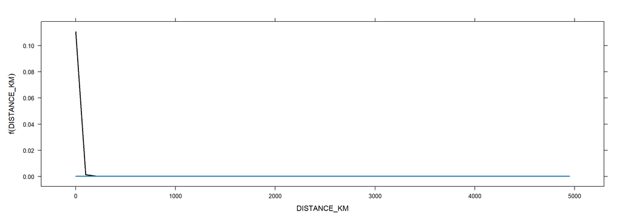

```r
# Figure 2 (right)
ml %>% # the %>% operator is read as "and then"
  partial(pred.var = "DISTANCE_KM") %>%
  plotPartial(smooth = TRUE, lwd = 2, ylab = expression(f(DISTANCE_KM)))
```

### Model validation

```r
# Extract the model predictions
p_ml <- predict(ml, data=training)
```

```
## Predicting.. Progress: 100%. Estimated remaining time: 0 seconds.
```

```r
# Join the predictions to the underlying df
df2 <- bind_cols(training, tibble("PRED_PROP_FLOWS" = p_ml$predictions))
```

Check how much the predicted sourcing proportions sum to (they should sum to 1 per slaughterhouse)

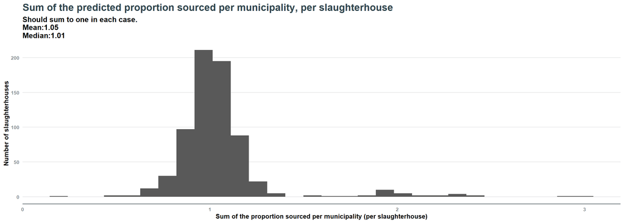

```r
proportion_summary <- df2 %>%
  group_by(CNPJ8, LH_GEOCODE) %>%
  summarise(SUM_PRED_PROP_FLOWS = sum(PRED_PROP_FLOWS)) %>%
  ungroup()
proportion_summary %>%
  ggplot(aes(SUM_PRED_PROP_FLOWS)) +
  geom_histogram() +
  theme_trase() +
  labs(title = "Sum of the predicted proportion sourced per municipality, per slaughterhouse",
       subtitle = glue("Should sum to one in each case.
       Mean:{round(mean(proportion_summary$SUM_PRED_PROP_FLOWS),2)}
       Median:{round(median(proportion_summary$SUM_PRED_PROP_FLOWS), 2)}"),
       y = "Number of slaughterhouses",
       x = "Sum of the proportion sourced per municipality (per slaughterhouse)")
```

Which are the cases with the excess predictions? (> 2)

```r
proportion_summary %>%
  filter(SUM_PRED_PROP_FLOWS > 2)
```

```
## # A tibble: 17 × 3
##    CNPJ8    LH_GEOCODE SUM_PRED_PROP_FLOWS
##    <chr>    <chr>                    <dbl>
##  1 01443795 1709500                   2.13
##  2 02225085 4217808                   2.32
##  3 02838996 3200706                   2.17
##  4 02916265 1504208                   2.41
##  5 02916265 5006200                   2.18
##  6 02916265 5103205                   2.95
##  7 03853896 5108402                   2.97
##  8 03910351 3131703                   2.02
##  9 04082624 1100114                   2.45
## 10 05164854 3143906                   2.03
## 11 06175831 4108403                   2.01
## 12 07328349 3541406                   2.31
## 13 07779699 5201108                   2.03
## 14 13177019 2805703                   2.25
## 15 47014923 3552106                   2.06
## 16 67620377 3505500                   2.29
## 17 82354317 4117800                   2.29
```

No obvious pattern - perhaps slaughterhouses surrounded by large municipalities? (in MT, MS).

Next, we rebase the proportions to 1, and visualise the in-sample correlation between observed and predicted:

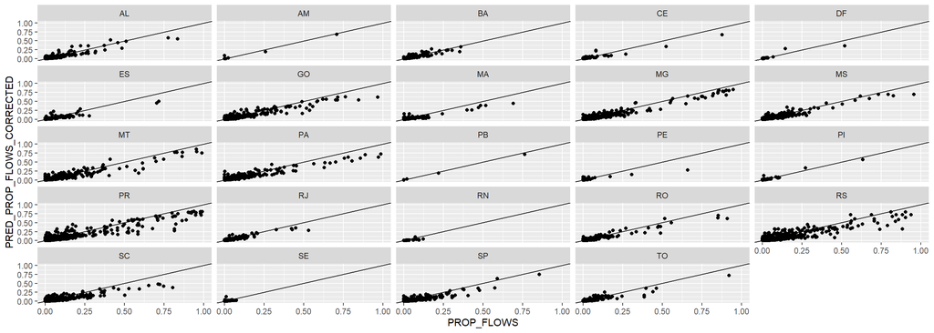

```r
# Compare the actual and predicted PROP_FLOWS
# ... Note, since the predicted PRED_PROP_FLOWS don't necessarily sum to one (for each slaughterhouse)
# ... I include a correction, were we re-base the PROP_FLOWS to sum to 1 (i.e. a true-proportion)
df2 %>%
  group_by(CNPJ8, LH_GEOCODE) %>%
  mutate(TOTAL_PRED_PROP_FLOWS = sum(PRED_PROP_FLOWS)) %>%
  ungroup() %>%
  mutate(PRED_PROP_FLOWS_CORRECTED = PRED_PROP_FLOWS / TOTAL_PRED_PROP_FLOWS) %>%
  ggplot(aes(PROP_FLOWS, PRED_PROP_FLOWS_CORRECTED)) +
  geom_point() +
  facet_wrap(~STATE) +
  geom_abline(slope = 1, intercept = 0) +
  scale_x_continuous(limits = c(0, 1)) +
  scale_y_continuous(limits = c(0, 1))
```

OOB, here fit with non-training data:

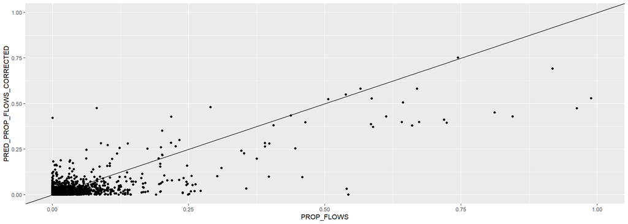

```r
# Extract the model predictions
test_predictions <- predict(ml, data=test)


# Compare the actual and predicted PROP_FLOWS
# ... Note, since the predicted PRED_PROP_FLOWS don't necessarily sum to one (for each slaughterhouse)
# ... I include a correction, were we re-base the PROP_FLOWS to sum to 1 (i.e. a true-proportion)
df2 <- bind_cols(test, tibble("PRED_PROP_FLOWS" = test_predictions$predictions))
df2 %>%
  group_by(CNPJ8, LH_GEOCODE) %>%
  mutate(TOTAL_PRED_PROP_FLOWS = sum(PRED_PROP_FLOWS)) %>%
  ungroup() %>%
  mutate(PRED_PROP_FLOWS_CORRECTED = PRED_PROP_FLOWS / TOTAL_PRED_PROP_FLOWS) %>%
  ggplot(aes(PROP_FLOWS, PRED_PROP_FLOWS_CORRECTED)) +
  geom_point() +
  geom_abline(slope = 1, intercept = 0) +
  scale_x_continuous(limits = c(0, 1)) +
  scale_y_continuous(limits = c(0, 1))
```

### Sensitivity

Compute the RF 20 times and collect statistics.

```r
ra_stats <- data.frame(rep=1:n, rsq=as.numeric(NA), mse=as.numeric(NA))
ra_importance <- vector(mode = "list", length = n)
for (i in 1:n) {
  model.ra <- ranger(data = training, PROP_FLOWS ~ REGION + TYPE + INSPECTION_LEVEL + NUM_HEAD + SIGSIF_PROP_FLOWS + DISTANCE_KM + NEIGHBOUR + SAME_STATE + LH_CLASSIFICATION + GEOCODE_CLASSIFICATION,
             importance = "permutation",
             write.forest = FALSE)
  ra_stats[i, "mse"] <- model.ra$prediction.error
  ra_stats[i, "rsq"] <- model.ra$r.squared
  model_importance <- importance(model.ra)
  ra_importance[[i]] <-
  tibble("VARIABLE" = names(model_importance),
         "VALUE" = model_importance)
  rm(model_importance, model.ra)
}
```

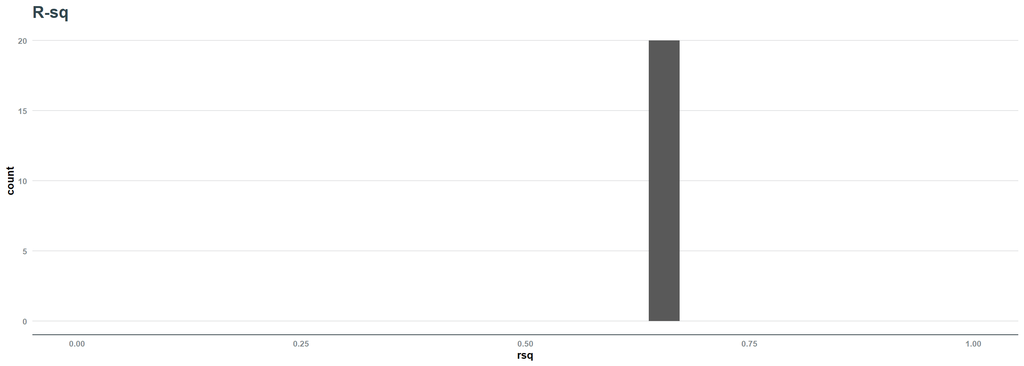

```r
# Rsq
p1 <- ggplot(data = ra_stats, aes(rsq)) +
  geom_histogram() +
  theme_trase() +
  labs(title = "R-sq") +
  scale_x_continuous(limits = c(0,1))
p2 <- ggplot(data = ra_stats, aes(mse)) +
  geom_histogram() +
  theme_trase() +
  labs(title = "MSE")
p1
```

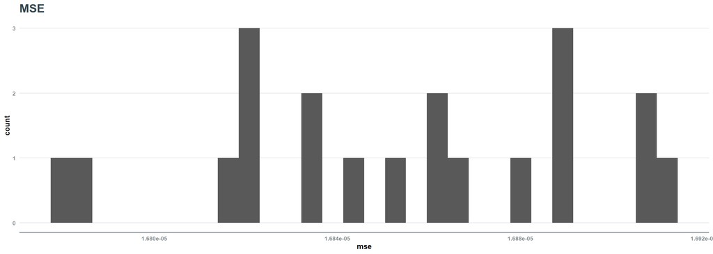

```r
p2
```

And the (stability of) the variable importance:

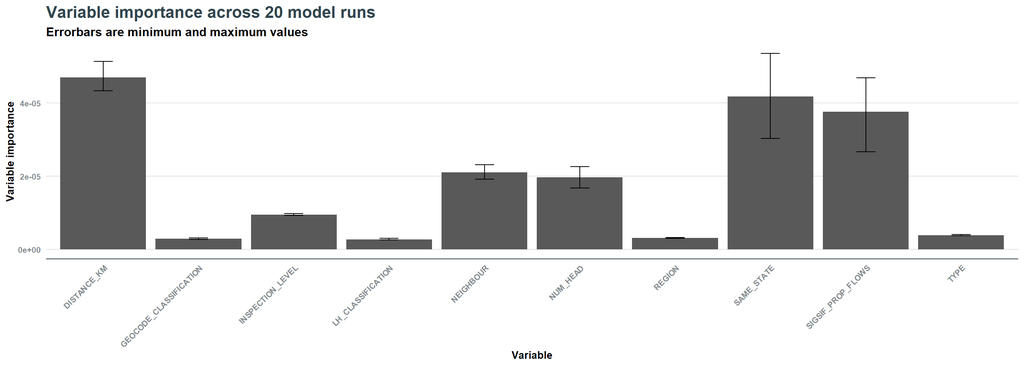

```r
bind_rows(ra_importance) %>%
  group_by(VARIABLE) %>%
  summarise(MEAN_VALUE = mean(VALUE),
            MIN_VALUE = min(VALUE),
            MAX_VALUE = max(VALUE)) %>%
  ungroup() %>%
  ggplot(aes(VARIABLE, MEAN_VALUE)) +
  geom_bar(stat = "identity") +
  geom_errorbar(aes(ymin = MIN_VALUE, ymax = MAX_VALUE), width = 0.2) +
  theme_trase() +
  theme(axis.text.x = element_text(angle = 45, hjust = 1)) +
  labs(title = glue("Variable importance across {n} model runs"),
       subtitle = "Errorbars are minimum and maximum values",
       y = "Variable importance",
       x = "Variable")
```

### Deforestation risk correlation

Does the deforestation risk correlate better than the raw supply shed (proportion sourced per municipality)?

```r
# Load pasture & cattle deforestation data, and production data
cd <- s3read_using(
  object = "data/DEFORESTATION/2024-02-15-br_mun_biome_pasture_cattle_deforestation_2013_2022_q4_2023_gee.csv",
  FUN = read_delim,
  delim = ",",
  bucket = "trase-app",
  opts = c("check_region" = T)
) %>%
  select(where(~!all(is.na(.x))))


# Past pasture deforestation
# ... Because we now use the full life cycle deforestation, we divide by five to get the mean per year ha/ton
# ... (in the previous version of the data we used the ANNUAL)
# ... this avoids double-counting across years, as 2018 pasture deforestation is calculated with deforestation in 2014-2018
ppd <-
  cd %>%
  mutate(GEOCODE = gsub("BR-", "", TRASE_ID)) %>%
  select(GEOCODE, PASDEFOR_2022, PASDEFOR_2021, PASDEFOR_2020, PASDEFOR_2019, PASDEFOR_2018) %>%
  pivot_longer(cols = c(PASDEFOR_2022, PASDEFOR_2021, PASDEFOR_2020, PASDEFOR_2019, PASDEFOR_2018),
               names_to = "YEAR",
               values_to = "VALUE") %>%
  group_by(GEOCODE) %>%
  summarise(PASTURE_DEFORESTATION = sum(VALUE) / 5) %>%
  ungroup()


# Past cattle deforestation
# ... Because we now use the full life cycle deforestation, we divide by five to get the mean per year ha/ton
# ... (in the previous version of the data we used the ANNUAL)
# ... this avoids double-counting across years
pcd <-
  cd %>%
  mutate(GEOCODE = gsub("BR-", "", TRASE_ID)) %>%
  select(GEOCODE, CATTLE_DEFOR_MUNBIO_FULL_2022, CATTLE_DEFOR_MUNBIO_FULL_2021, CATTLE_DEFOR_MUNBIO_FULL_2020, CATTLE_DEFOR_MUNBIO_FULL_2019,CATTLE_DEFOR_MUNBIO_FULL_2018) %>%
  pivot_longer(cols = c(CATTLE_DEFOR_MUNBIO_FULL_2022, CATTLE_DEFOR_MUNBIO_FULL_2021, CATTLE_DEFOR_MUNBIO_FULL_2020, CATTLE_DEFOR_MUNBIO_FULL_2019,CATTLE_DEFOR_MUNBIO_FULL_2018),
               names_to = "YEAR",
               values_to = "VALUE") %>%
  group_by(GEOCODE) %>%
  summarise(CATTLE_DEFORESTATION_FULL = sum(VALUE) / 5) %>%
  ungroup()


# Merge into a single df
ppd <- full_join(ppd, pcd, by = "GEOCODE") %>%
  mutate(CATTLE_DEFORESTATION_FULL = replace_na(CATTLE_DEFORESTATION_FULL, 0),
         PASTURE_DEFORESTATION = replace_na(PASTURE_DEFORESTATION, 0))
```

```r
# Add deforestation data to the supply sheds
# NB I use the cattle deforestation per THOUSAND tons of carcass
df_deforestation <- df2 %>%
  group_by(CNPJ8, LH_GEOCODE) %>%
  mutate(TOTAL_PRED_PROP_FLOWS = sum(PRED_PROP_FLOWS)) %>%
  ungroup() %>%
  mutate(PRED_PROP_FLOWS_CORRECTED = PRED_PROP_FLOWS / TOTAL_PRED_PROP_FLOWS) %>%
  left_join(ppd, ., by = "GEOCODE") %>%
  mutate(WEIGHTED_CATTLE_DEF = PROP_FLOWS * CATTLE_DEFORESTATION_FULL * 1000,
         WEIGHTED_CATTLE_DEF_PRED = PRED_PROP_FLOWS_CORRECTED * CATTLE_DEFORESTATION_FULL * 1000) %>%
  group_by(CNPJ8, LH_GEOCODE) %>%
  summarise(SUM_CD_ORIGINAL = sum(WEIGHTED_CATTLE_DEF, na.rm = T),
            SUM_CD_PRED = sum(WEIGHTED_CATTLE_DEF_PRED, na.rm = T)) %>%
  ungroup() %>%
  mutate(DFRS_SOURCE = "GTA")


# Check the deforestation correlation
df_model <- lm(data = df_deforestation, SUM_CD_ORIGINAL ~ SUM_CD_PRED)
```

Th r-sq of the deforestation model is: 0.8884133.

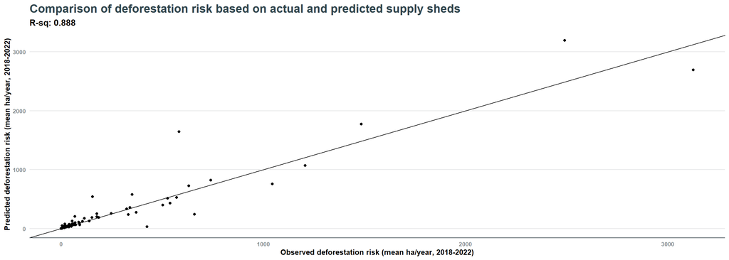

```r
#
ggplot(data = df_deforestation, aes(SUM_CD_ORIGINAL, SUM_CD_PRED)) +
  geom_point() +
  geom_abline(slope = 1, intercept = 0) +
  labs(y = "Predicted deforestation risk (mean ha/year, 2018-2022)",
       x = "Observed deforestation risk (mean ha/year, 2018-2022)",
       title = "Comparison of deforestation risk based on actual and predicted supply sheds",
       subtitle = glue("R-sq: {round(summary(df_model)$r.squared, 3)}")) +
  theme_trase() +
  NULL
```

### Predict supply sheds

For the slaughterhouses where we do not have GTAs, predict the supply shed.

```r
# Build the dataset for prediction
# ... this requires adding a row per municipality in the country, per slaughterhouse
# ... and also filtering to ABATEDOURO/MATADOUROs
# ... for the rest (ENTREPOSTO FRIGORIFICO, UNIDADE DE BENEFICIAMENTO), they don't usually buy cattle directly
# ...a also I drop cases where the municipality-pairs have no transport data
# ... this is mostly cases to MUANÁ, PA or PEDRA BRANCA DO AMAPARI, AP where there
# ... are few cattle and the travel algorithm failed to find solutions, due to crossing
# ... the Amazon, I suppose
lh_missing <- lh %>%
  anti_join(ss, by = c("CNPJ8", "LH_GEOCODE")) %>%
  select(CNPJ8, LH_GEOCODE, REGION, STATE, TYPE, INSPECTION_LEVEL) %>%
  filter(grepl("ABATEDOURO|MATADOURO", TYPE))
lh_missing_list <- split(lh_missing, seq(nrow(lh_missing)))
for(i in 1:nrow(lh_missing)){
  lh_missing_list[[i]] <- bind_cols(lh_missing_list[[i]], munis_df) %>%
    select(-ROW_ID)
}
lh_missing_df <- bind_rows(lh_missing_list) %>%
  left_join(ppm_2022, by = "GEOCODE", relationship = "many-to-one") %>%
  left_join(urban, by = c("LH_GEOCODE" = "GEOCODE"), relationship = "many-to-one") %>%
  rename(LH_CLASSIFICATION = MUNI_CLASSIFICATION) %>%
  left_join(urban, by = c("GEOCODE" = "GEOCODE"), relationship = "many-to-one") %>%
  rename(GEOCODE_CLASSIFICATION = MUNI_CLASSIFICATION) %>%
  left_join(sigsif_summary, by = c("STATE" = "STATE_SLAUGHTER", "GEOCODE")) %>%
  mutate(NUM_HEAD = replace_na(NUM_HEAD, 0),
         SIGSIF_PROP_FLOWS = replace_na(SIGSIF_PROP_FLOWS, 0)) %>%
  left_join(dist_matrix, by = c("LH_GEOCODE" = "DESTINATION", "GEOCODE" = "ORIGIN")) %>%
  left_join(neighbour_all_df, by = c("LH_GEOCODE" = "FOCAL_GEOCODE", "GEOCODE" = "NEIGHBOUR_GEOCODE")) %>%
  mutate(NEIGHBOUR = ifelse(is.na(NEIGHBOUR), "NOT NEIGHBOUR", NEIGHBOUR)) %>%
  mutate(SAME_STATE = ifelse(str_sub(LH_GEOCODE, start = 1, end = 2) == str_sub(GEOCODE, start = 1, end = 2), TRUE, FALSE)) %>%
  drop_na(LH_CLASSIFICATION) %>%
  drop_na(GEOCODE_CLASSIFICATION) %>%
  drop_na(SAME_STATE) %>%
  drop_na(DISTANCE_KM) %>%
  drop_na(GEOCODE)


# Add in the distance to the nearest SIF/SIE slaughterhouse (which is no the slaughterhouse-of-interest)
# NB a small number of duplicate rows are introduced, but this won't affect the modelling much
chk <- nrow(lh_missing_df)
lh_missing_df <- inner_join(lh_missing_df,
                 sif_distances,
                 by = c("GEOCODE" = "ORIGIN"),
                 relationship = "many-to-many") %>%
  filter(CNPJ8 != CNPJ8_SIF) %>%
  group_by(CNPJ8, LH_GEOCODE, GEOCODE, INSPECTION_LEVEL, TYPE) %>%
  filter(DISTANCE_KM_TO_NEXT_NEAREST_SIF == min(DISTANCE_KM_TO_NEXT_NEAREST_SIF)) %>%
  slice(1) %>%
  ungroup() %>%
  select(-CNPJ8_SIF) %>%
  inner_join(sie_distances,
             by = c("GEOCODE" = "ORIGIN"),
             relationship = "many-to-many") %>%
  filter(CNPJ8 != CNPJ8_SIE) %>%
  group_by(CNPJ8, LH_GEOCODE, GEOCODE, INSPECTION_LEVEL, TYPE) %>%
  filter(DISTANCE_KM_TO_NEXT_NEAREST_SIE == min(DISTANCE_KM_TO_NEXT_NEAREST_SIE)) %>%
  slice(1) %>%
  ungroup() %>%
  select(-CNPJ8_SIE) %>%
  distinct()


# Check there are no NAs in the data set
# map_lgl(df, ~ any(is.na(.x)))
stopifnot(sum(is.na(lh_missing_df)) == 0)


# Model prediction
# Extract the model predictions
ss_predictions <- predict(ml, data=lh_missing_df)
```

```
## Predicting.. Progress: 63%. Estimated remaining time: 18 seconds.
```

```r
# Compare the actual and predicted PROP_FLOWS
# ... Note, since the predicted PRED_PROP_FLOWS don't necessarily sum to one (for each slaughterhouse)
# ... I include a correction, were we re-base the PROP_FLOWS to sum to 1 (i.e. a true-proportion)
lh_missing_df <- bind_cols(lh_missing_df, tibble("PRED_PROP_FLOWS" = ss_predictions$predictions))
```

Check the distribution of the modelled values

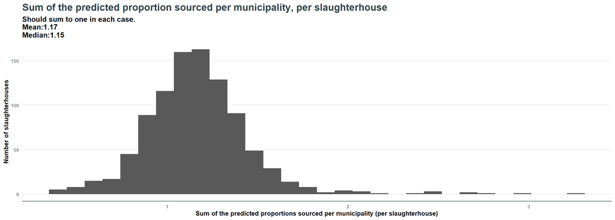

```r
proportion_summary <- lh_missing_df %>%
  group_by(CNPJ8, LH_GEOCODE) %>%
  summarise(SUM_PRED_PROP_FLOWS = sum(PRED_PROP_FLOWS)) %>%
  ungroup()
proportion_summary %>%
  ggplot(aes(SUM_PRED_PROP_FLOWS)) +
  geom_histogram() +
  theme_trase() +
  labs(title = "Sum of the predicted proportion sourced per municipality, per slaughterhouse",
     subtitle = glue("Should sum to one in each case.
     Mean:{round(mean(proportion_summary$SUM_PRED_PROP_FLOWS),2)}
     Median:{round(median(proportion_summary$SUM_PRED_PROP_FLOWS), 2)}"),
     y = "Number of slaughterhouses",
     x = "Sum of the predicted proportions sourced per municipality (per slaughterhouse)")
```

Then we rebase the proportions (per slaughterhouse) to sum to one.

Note: I drop municipalities with predicted volumes < 0.01% of flows, in order to reduce the size of the data.

```r
# Rebase the predictions so they sum to 1 (per slaughterhouse)
lh_missing_df <- lh_missing_df %>%
  filter(PRED_PROP_FLOWS > 0.0001) %>%
  group_by(CNPJ8, LH_GEOCODE) %>%
  mutate(TOTAL_PRED_PROP_FLOWS = sum(PRED_PROP_FLOWS),
         PRED_PROP_FLOWS_CORRECTED = PRED_PROP_FLOWS / unique(TOTAL_PRED_PROP_FLOWS)) %>%
  ungroup() %>%
  select(CNPJ8, LH_GEOCODE, GEOCODE, PRED_PROP_FLOWS_CORRECTED) %>%
  filter(PRED_PROP_FLOWS_CORRECTED > 0) %>%
  group_by(CNPJ8, LH_GEOCODE) %>%
  nest(SUPPLY_SHED = c(GEOCODE, PRED_PROP_FLOWS_CORRECTED)) %>%
  ungroup()


# tidy up
rm(ppm, ppm_2022, dist_matrix, ss, lh, mean_muni_size, muni_size, ml, ss_predictions,
   lh_missing_list, lh_missing)
```

### Visualise predicted supply sheds

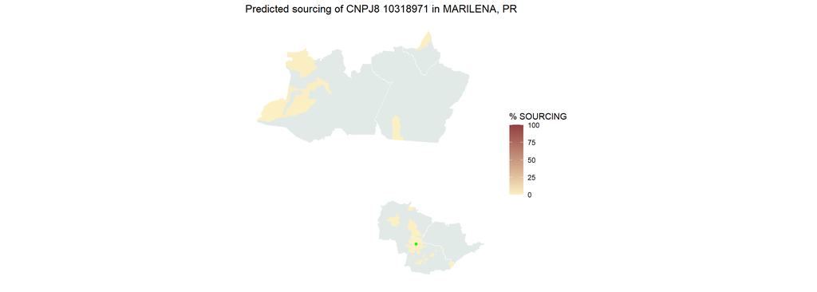

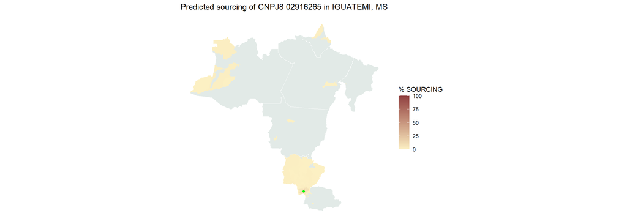

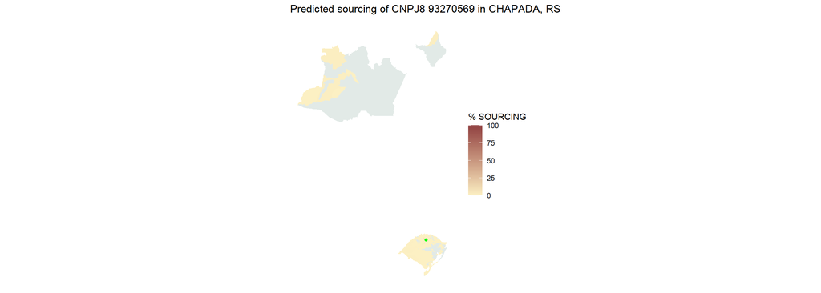

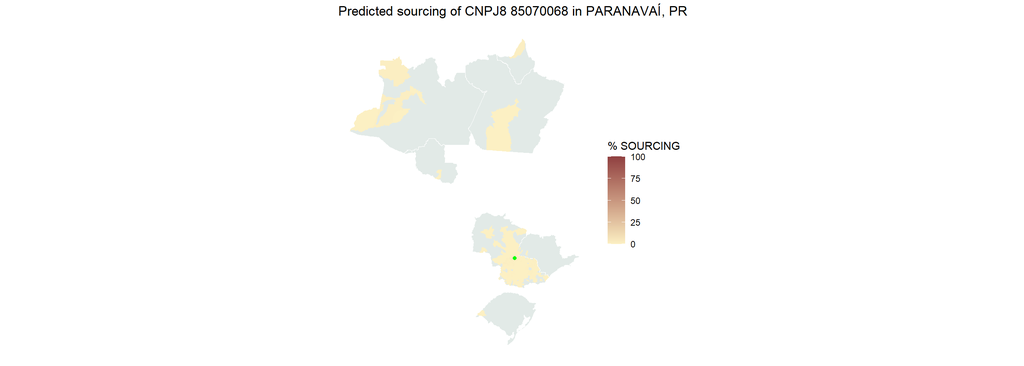

```r
fn_plot_predicted_supply_sheds <- function(CNPJ8, LH_GEOCODE, SUPPLY_SHED, muni_centroids, states, scale_max) {
  munis_to_plot <-
    inner_join(munis, SUPPLY_SHED, by = c("GEOCODE" = "GEOCODE")) %>%
    mutate(TWO_DIGIT_CODE = str_sub(GEOCODE, start = 1, end = 2)) %>%
    left_join(state_dic, by = "TWO_DIGIT_CODE")
  location <-
    muni_centroids %>%
    filter(GEOCODE == LH_GEOCODE) %>%
    mutate(
      x = map_dbl(geometry, 1),
      y = map_dbl(geometry, 2),
      TWO_DIGIT_CODE = str_sub(GEOCODE, start = 1, end = 2)
    ) %>%
    left_join(state_dic, by = "TWO_DIGIT_CODE")
  p <- ggplot() +
    geom_sf(data = states %>% filter(NM_ESTADO %in% unique(munis_to_plot$STATE_NAME)), fill = trase_country_background, col = trase_map_border) +
    geom_sf(data = munis_to_plot, aes(fill = PRED_PROP_FLOWS_CORRECTED * 100), col = NA) +
    geom_point(data = location, aes(x = x, y = y), col = "green") +
    scale_fill_gradient(
    name = bquote('% SOURCING'),
    low = trase_palettes$MapsNegative[[1]],
    high = trase_palettes$MapsNegative[[9]],
    limits = c(0, 100)
  ) +
    theme_minimal() +
    coord_sf(datum = NA) +
    labs(
      title = paste0("Predicted sourcing of CNPJ8 ", CNPJ8, " in ", location$NAME, ", ", location$STATE_ABBR)
    ) +
    theme(axis.title = element_blank())
  return(p)
}
pmap(
  .l = lh_missing_df %>% sample_n(size = 4),
  .f = fn_plot_predicted_supply_sheds,
  muni_centroids = muni_centroids,
  states = states
)
```

### Export predicted data

```r
zz <- rawConnection(raw(0), "r+")
lh_missing_df %>%
  toJSON(pretty = T, Date = "ISO8601", quote = T, null = "list") %>%
  write_lines(zz)
aws.s3::put_object(
  file = rawConnectionValue(zz),
  bucket = "trase-storage",
  object = "brazil/logistics/gta/network/BOV/SUPPLY_SHED/2024_MUNICIPAL_PER_CNPJ8/JSON/CNPJ8_SUPPLY_SHEDS_PREDICTED.json",
  check_region = T)
```

```
## [1] TRUE
```

```r
close(zz)
rm(zz)
```

### Acknowledgements

Resources that I found useful when writing this were: https://www.css.cornell.edu/faculty/dgr2/_static/files/R_html/CompareRandomForestPackages.html https://brunaw.com/slides/rladies-dublin/RF/intro-to-rf.html